# 2018-11 MSc_assembly_stats

Yannick Wurm - https://wurmlab.github.io

## Quick analysis

We gave students one of three datasets (same amount of data; different amounts of cleaning & genetic diversity). Each student performed a genome assembly.

```r
params <- read.csv("input/AssignmentParametersForScreenshot.csv")
kable(params)
```

| Student.ID | Dataset | Assembler | Parameters | Note |
| --- | --- | --- | --- | --- |
| 140355664 | input1 | masurca 3.2.8 | CA_PARAMETERS = cgwErrorRate=0.15 ovlErrorRate=0.04 |  |
| 150346599 | input2 | masurca 3.2.8 | CA_PARAMETERS = cgwErrorRate=0.15 ovlErrorRate=0.04 |  |
| 150434922 | input3 | masurca 3.2.8 | CA_PARAMETERS = cgwErrorRate=0.15 ovlErrorRate=0.04 |  |
| 170857044 | input1 | spades 3.11.1 | –only-assembler -k 21,33,55,77 |  |
| 170941022 | input2 | spades 3.11.1 | –only-assembler -k 21,33,55,77 |  |
| 180103616 | input3 | spades 3.11.1 | –only-assembler -k 21,33,55,77 |  |
| 180209871 | input1 | /data/SBCS-MSc-BioInf/2018/run_stride_1.sh | params are set directly in the script |  |
| 180279704 | input2 | /data/SBCS-MSc-BioInf/2018/run_stride_1.sh | params are set directly in the script |  |
| 180279863 | input3 | /data/SBCS-MSc-BioInf/2018/run_stride_1.sh | params are set directly in the script |  |
| 180330348 | input1 | soapdenovo r241 | -K 45 | (note that K is uppercase) |
| 180339411 | input2 | soapdenovo r241 | -K 45 | (note that K is uppercase) |
| 180601400 | input3 | soapdenovo r241 | -K 45 | (note that K is uppercase) |
| 180603378 | input1 | masurca 3.2.8 | CA_PARAMETERS = cgwErrorRate=0.15 ovlErrorRate=0.06 |  |
| 180609060 | input2 | masurca 3.2.8 | CA_PARAMETERS = cgwErrorRate=0.15 ovlErrorRate=0.06 |  |
| 180703634 | input3 | masurca 3.2.8 | CA_PARAMETERS = cgwErrorRate=0.15 ovlErrorRate=0.06 |  |
| 180788088 | input1 | spades 3.11.1 | –only-assembler -k 33,55,77,101 |  |
| 180790715 | input2 | spades 3.11.1 | –only-assembler -k 33,55,77,101 |  |
| 180791055 | input3 | spades 3.11.1 | –only-assembler -k 33,55,77,101 |  |
| 180822555 | input1 | /data/SBCS-MSc-BioInf/2018/run_stride_2.sh | params are set directly in the script |  |
| 180832277 | input2 | /data/SBCS-MSc-BioInf/2018/run_stride_2.sh | params are set directly in the script |  |
| 180330348 | input3 | /data/SBCS-MSc-BioInf/2018/run_stride_2.sh | params are set directly in the script |  |
| 180940479 | input1 | soapdenovo r241 | -K 65 | (note that K is uppercase) |
| 180946806 | input2 | soapdenovo r241 | -K 65 | (note that K is uppercase) |
| 180957514 | input3 | soapdenovo r241 | -K 65 | (note that K is uppercase) |
| 180962840 | input1 | masurca 3.2.8 | CA_PARAMETERS = cgwErrorRate=0.15 ovlErrorRate=0.08 |  |
| 180986905 | input2 | masurca 3.2.8 | CA_PARAMETERS = cgwErrorRate=0.15 ovlErrorRate=0.08 |  |
| 180991611 | input3 | masurca 3.2.8 | CA_PARAMETERS = cgwErrorRate=0.15 ovlErrorRate=0.08 |  |
| 181040015 | input1 | masurca 3.2.2 | CA_PARAMETERS = cgwErrorRate=0.15 ovlErrorRate=0.04 |  |
| 180928329 | input2 | masurca 3.2.2 | CA_PARAMETERS = cgwErrorRate=0.15 ovlErrorRate=0.06 |  |

## Results

```r
assemblies_raw <- read.csv("input/responses.csv")

# google's F!*@$&# csv includes 1,000,000 commas to delimit thousands. Need to clean up
assemblies_raw$n50       <- as.numeric(gsub(x = assemblies_raw$n50,
                                        pattern = ",",
                                        replacement = ""))
assemblies_raw$l50        <- as.numeric(gsub(x = assemblies_raw$l50,
                                         pattern = ",",
                                         replacement = ""))
assemblies_raw$total_size <- as.numeric(gsub(x = assemblies_raw$total_size,
                                         pattern = ",",
                                         replacement = ""))

# removing duplicate rows (due to student submitting twice OR using backup dataset)
# (will also remove any duplicated due to same params being used twice)
assemblies <- subset(assemblies_raw, subset =  !duplicated(subset(assemblies_raw, select = c(n50, l50, total_size))) )


head(assemblies)
```

```
##   student_id    n50   l50 total_size
## 1  180601400 203698   308  234694233
## 2  180609060 119895   605  245035513
## 3  170857044  41759  1448  229125407
## 4  180603378   1334 33363  136766789
## 5  180822555  24382  2545  228282698
## 7  180330348 108318   571  234572671
```

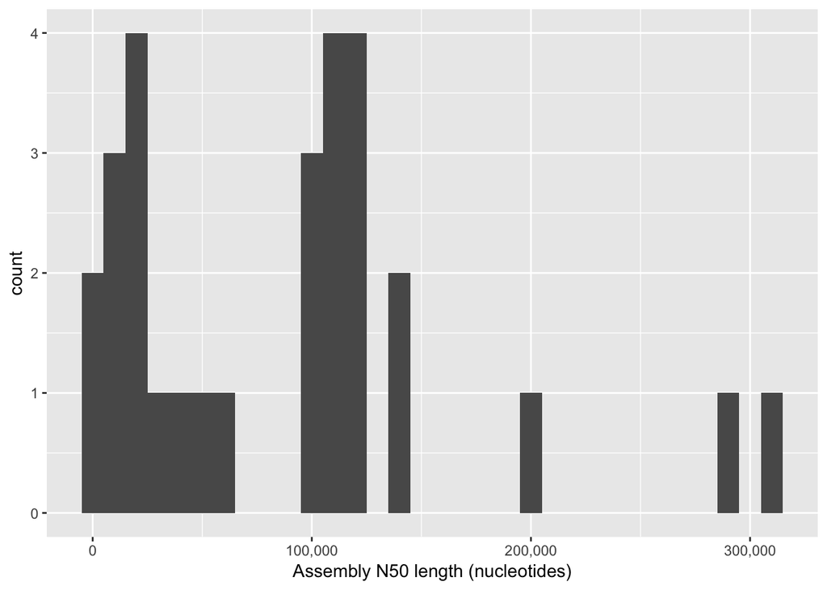

```r
ggplot(assemblies, aes(x = n50)) + geom_histogram(binwidth = 10000) +
  scale_x_continuous(name = "Assembly N50 length (nucleotides)", labels = scales::comma)
```

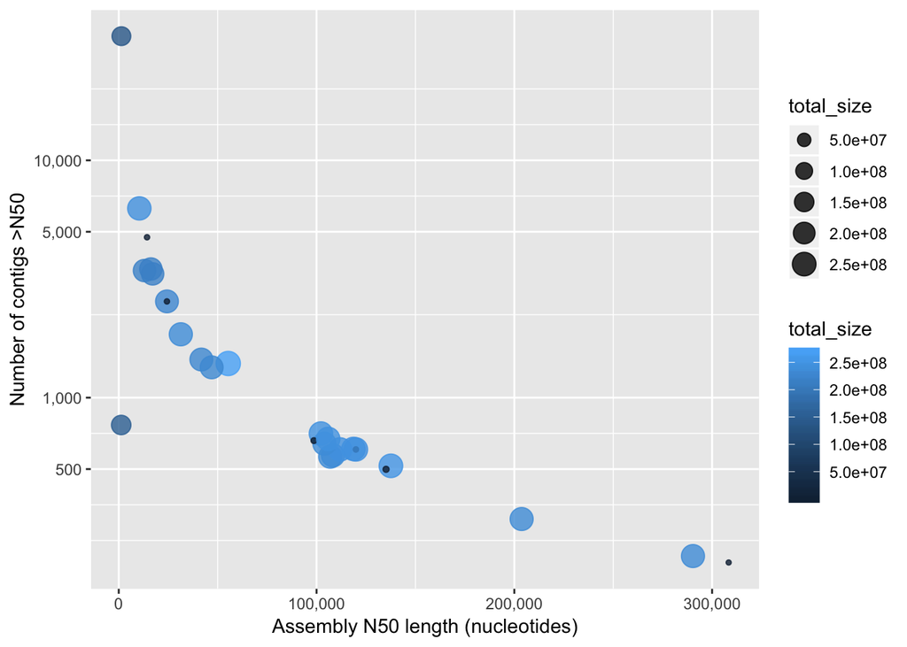

```r
ggplot(assemblies, aes(x = n50, y = l50, color = total_size, size=total_size)) + geom_point(alpha=0.8) +
  scale_x_continuous(name = "Assembly N50 length (nucleotides)", labels = scales::comma) +
  scale_y_log10(name = "Number of contigs >N50", breaks = c(10,50,100,500,1000,5000,10000,50000), labels = scales::comma)
```

Huge impact of assembly params. Some noise in the data - e.g. see variation in overall assembly size which we do not expect. Some of this is likely due to human error, or because assembly didn’t finish (e.g. biggest N50 comes from 1 subfolder of spades output). Some noise likely real.

## Conclusions / Thoughts

Huge impact of assembly params.

Would be great to see structure of data:

- by assembler
- by input dataset (cleaning approach)
- potentially by kmer size

Need to be wary that bigger N50 is not necessarily better. Can we use synteny to (e.g.) terrestris to ensure that the biggest assemblies aren’t problematic?

Are we missing 50Mb of data (highly repetitive?) or was flow cytometry incorrect?